# 07-03. 워드 임베딩 (ELMo, 임베딩 벡터 시각화, 문서 벡터, 문서 임베딩, Doc2Vec)

## 엘모(Embeddings from Language Model, ELMo)

논문 링크 : https://aclweb.org/anthology/N18-1202

- ELMo(Embeddings from Language Model)는 2018년에 제안된 새로운 워드 임베딩 방법론
- **ELMo는 '언어 모델로 하는 임베딩'**
- **ELMo의 가장 큰 특징은 사전 훈련된 언어 모델(Pre-trained language model)을 사용**

```
현재 tensorflow 2.0에서는 TF-Hub의 ELMo를 사용할 수 없음.
사용하려면 tensorflow 버전을 1버전으로 하향 필요
```

### ELMo(Embeddings from Language Model)

- Bank Account(은행 계좌)와 River Bank(강둑)에서의 Bank는 전혀 다른 의미를 가지는데,

  Word2Vec이나 GloVe 등으로 표현된 임베딩 벡터들은 이를 제대로 반영하지 못한다는 단점

  ```
  예) Word2Vec이나 GloVe 등의 임베딩 방법론으로 Bank란 단어를 [0.2 0.8 -1.2]라는 임베딩 벡터로 임베딩하였다고 하면,
  이 단어는 Bank Account(은행 계좌)와 River Bank(강둑)에서의 Bank는
  전혀 다른 의미임에도 불구하고 두 가지 상황 모두에서 [0.2 0.8 -1.2]의 벡터가 사용
  ```

- **워드 임베딩 시 문맥을 고려해서 임베딩을 하겠다는 아이디어가 문맥을 반영한 워드 임베딩(Contextualized Word Embedding)**

### biLM(Bidirectional Language Model)의 사전 훈련

- 은닉층이 2개인 일반적인 단방향 RNN 언어 모델의 언어 모델

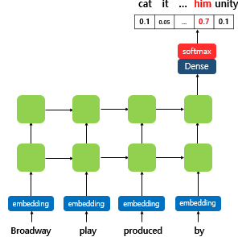

- RNN 언어 모델은 문장으로부터 단어 단위로 입력을 받는데, RNN 내부의 은닉 상태 $h_t$는 시점(time step)이 지날수록 점점 업데이트
  - 결과적으로 RNN의 $h_t$의 값이 문장의 문맥 정보를 점차적으로 반영
- **ELMo는 위의 그림의 순방향 RNN 뿐만 아니라, 위의 그림과는 반대 방향으로 문장을 스캔하는 역방향 RNN 또한 활용**
  - **ELMo는 양쪽 방향의 언어 모델을 둘 다 학습하여 활용한다고하여, 이 언어 모델을 biLM(Bidirectional Language Model)**

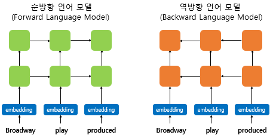

- biLM의 각 시점의 입력이 되는 단어 벡터는 합성곱 신경망을 이용한 문자 임베딩(character embedding)을 통해 얻은 단어 벡터

#### 양방향 RNN과 ELMo에서의 biLM은 다름

- 양방향 RNN은 순방향 RNN의 은닉 상태와, 역방향의 RNN의 은닉 상태를 연결(concatenate)하여 다음층의 입력으로 사용
- 반면, biLM의 순방향 언어모델과 역방향 언어모델이라는 두 개의 언어 모델을 별개의 모델로 보고 학습

### biLM의 활용

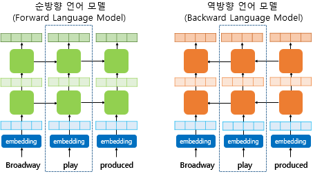

- `play`란 단어가 임베딩이 되고 있다는 가정
  - `play`라는 단어를 임베딩 하기위해서 ELMo는 위의 점선의 사각형 내부의 각 층의 결과값을 재료로 사용
  - 해당 시점(time step)의 BiLM의 각 층의 출력값을 가져오며, 순방향 언어 모델과 역방향 언어 모델의 각 층의 출력값을 연결(concatenate)하고 추가 작업을 진행
- 각 층의 출력값이란 첫번째는 임베딩 층을 말하며, 나머지 층은 각 층의 은닉 상태
- ELMo의 직관적인 아이디어는 각 층의 출력값이 가진 정보는 전부 서로 다른 종류의 정보를 갖고 있을 것이므로, 이들을 모두 활용한다는 점

### ELMo가 임베딩 벡터를 얻는 과정

#### 1. 각 층의 출력값을 연결(concatenate)한다.

#### 2. 각 층의 출력값 별로 가중치를 준다.

#### 3. 각 층의 출력값을 모두 더한다.

- 가중합(Weighted Sum)

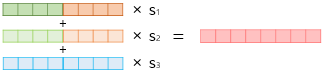

#### 4. 벡터의 크기를 결정하는 스칼라 매개변수 $\gamma$를 곱한다.

**완성된 벡터를 ELMo 표현(representation)**

#### 텍스트 분류 작업에서의 ELMo 표현

- ELMo 표현을 기존의 임베딩 벡터와 함께 사용
  1. 우선 텍스트 분류 작업을 위해서 GloVe와 같은 기존의 방법론을 사용한 임베딩 벡터를 준비
  2. **GloVe를 사용한 임베딩 벡터만 텍스트 분류 작업에 사용하는 것이 아니라, 준비된 ELMo 표현을 GloVe 임베딩 벡터와 연결(concatenate)해서 입력으로 사용**
  3. 이때 biLM의 가중치는 고정시키고, 위에서 사용한 $s_1, s_2, s_3$과 $\gamma$는 훈련 과정에서 학습

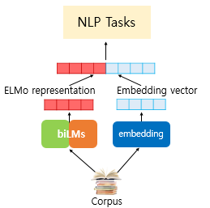

## 임베딩 벡터 시각화(Embedding Visualization)

- 시각화를 위해서는 이미 모델을 학습하고, 파일로 저장되어져 있어야함
- 모델이 저장되어져 있다면 아래 커맨드를 통해 시각화에 필요한 파일들을 생성

```
!python -m gensim.scripts.word2vec2tensor --input 모델이름 --output 모델이름
```

- `모델이름_metadata.tsv`와 `모델이름_tensor.tsv` 두 개 파일 생성
  - 임베딩 벡터 시각화에 사용할 파일

```
!python -m gensim.scripts.word2vec2tensor --input 모델이름 --output 모델이름
```

#### 임베딩 프로젝터를 사용하여 시각화

링크 : https://projector.tensorflow.org/

## 문서 임베딩 : 워드 임베딩의 평균(Average Word Embedding)

### 문서 벡터를 이용한 추천 시스템 실습 (Recommendation System using Document Embedding)

- **단어 벡터를 얻은 뒤 문서에 존재하는 단어 벡터들의 평균을 문서 벡터로 간주가능**

#### 데이터 로드

데이터 다운로드 링크 : https://drive.google.com/file/d/15Q7DZ7xrJsI2Hji-WbkU9j1mwnODBd5A/view?usp=sharing

```python
import urllib.request
import pandas as pd
import numpy as np
import matplotlib.pyplot as plt
import requests
import re
from PIL import Image
from io import BytesIO
from nltk.tokenize import RegexpTokenizer
import nltk
nltk.download('stopwords')

from gensim.models import Word2Vec
from gensim.models import KeyedVectors
from nltk.corpus import stopwords
from sklearn.metrics.pairwise import cosine_similarity
```

```python
urllib.request.urlretrieve("https://raw.githubusercontent.com/ukairia777/tensorflow-nlp-tutorial/main/09.%20Word%20Embedding/dataset/data.csv", filename="data.csv")
df = pd.read_csv("data.csv")
print('전체 문서의 수 :',len(df))
```

```
전체 문서의 수 : 2382
```

```python
df.head(5)
```

|  | Unnamed: 0.1 | Desc | Unnamed: 0 | author | genre | image_link | rating | title |
| --- | --- | --- | --- | --- | --- | --- | --- | --- |
| 0 | 0 | We know that power is shifting: From West to E... | 0.0 | Moisés Naím | Business | https://i.gr-assets.com/images/S/compressed.ph... | 3.63 | The End of Power: From Boardrooms to Battlefie... |
| 1 | 1 | Following the success of The Accidental Billio... | 1.0 | Blake J. Harris | Business | https://i.gr-assets.com/images/S/compressed.ph... | 3.94 | Console Wars: Sega, Nintendo, and the Battle t... |
| 2 | 2 | How to tap the power of social software and ne... | 2.0 | Chris Brogan | Business | https://i.gr-assets.com/images/S/compressed.ph... | 3.78 | Trust Agents: Using the Web to Build Influence... |
| 3 | 3 | William J. Bernstein is an American financial ... | 3.0 | William J. Bernstein | Business | https://i.gr-assets.com/images/S/compressed.ph... | 4.20 | The Four Pillars of Investing |
| 4 | 4 | Amazing book. And I joined Steve Jobs and many... | 4.0 | Akio Morita | Business | https://i.gr-assets.com/images/S/compressed.ph... | 4.05 | Made in Japan: Akio Morita and Sony |

#### 데이터 전처리

1. 불필요한 열 제거
2. 줄거리에 해당하는 열 `Desc`에 있는 데이터에 대해서 Word2Vec을 학습하기 위해 전처리를 진행

```python
# Ascii 제거
def _removeNonAscii(s):
    return "".join(i for i in s if  ord(i)<128)

# 소문자 변환
def make_lower_case(text):
    return text.lower()

# 불용어 제거
def remove_stop_words(text):
    text = text.split()
    stops = set(stopwords.words("english"))
    text = [w for w in text if not w in stops]
    text = " ".join(text)
    return text

# html 코드 제거
def remove_html(text):
    html_pattern = re.compile('<.*?>')
    return html_pattern.sub(r'', text)

# 문장부호, 구두점 제거
def remove_punctuation(text):
    tokenizer = RegexpTokenizer(r'[a-zA-Z]+')
    text = tokenizer.tokenize(text)
    text = " ".join(text)
    return text
```

```python
df['cleaned'] = df['Desc'].apply(_removeNonAscii)
df['cleaned'] = df.cleaned.apply(make_lower_case)
df['cleaned'] = df.cleaned.apply(remove_stop_words)
df['cleaned'] = df.cleaned.apply(remove_punctuation)
df['cleaned'] = df.cleaned.apply(remove_html)
```

```python
df['cleaned'].head(5)
```

```
0    know power shifting west east north south pres...
1    following success accidental billionaires mone...
2    tap power social software networks build busin...
3    william j bernstein american financial theoris...
4    amazing book joined steve jobs many akio morit...
Name: cleaned, dtype: object
```

#### 결측값 및 공백값 제거

```python
df['cleaned'].replace('', np.nan, inplace=True)
df = df[df['cleaned'].notna()]
print('전체 문서의 수 :',len(df))
```

```
전체 문서의 수 : 2381
```

#### 토큰화 수행

```python
corpus = []
for words in df['cleaned']:
    corpus.append(words.split())
```

#### 사전 훈련된 워드 임베딩 사용

```python
word2vec_model = KeyedVectors.load_word2vec_format('GoogleNews-vectors-negative300.bin.gz', binary=True)
```

```python
word2vec_model = Word2Vec(size = 300, window=5, min_count = 2, workers = -1)
word2vec_model.build_vocab(corpus)
word2vec_model.intersect_word2vec_format('GoogleNews-vectors-negative300.bin.gz', lockf=1.0, binary=True)
word2vec_model.train(corpus, total_examples = word2vec_model.corpus_count, epochs = 15)
```

```
(0, 0)
```

#### 단어 벡터의 평균계산

```python
def get_document_vectors(document_list):
    document_embedding_list = []

    # 각 문서에 대해서
    for line in document_list:
        doc2vec = None
        count = 0

        for word in line.split():

            if word in word2vec_model.wv.vocab:
                count += 1
                # 해당 문서에 있는 모든 단어들의 벡터값을 더한다.
                if doc2vec is None:
                    doc2vec = word2vec_model[word]
                else:
                    doc2vec = doc2vec + word2vec_model[word]

        if doc2vec is not None:
            # 단어 벡터를 모두 더한 벡터의 값을 문서 길이로 나눠준다.
            doc2vec = doc2vec / count
            document_embedding_list.append(doc2vec)

    # 각 문서에 대한 문서 벡터 리스트를 리턴
    return document_embedding_list
```

```python
document_embedding_list = get_document_vectors(df['cleaned'])
```

```python
print('문서 벡터의 수 :',len(document_embedding_list))
```

```
문서 벡터의 수 : 2381
```

#### 추천 시스템 구현

- 각 문서 벡터 간의 코사인 유사도

```python
cosine_similarities = cosine_similarity(document_embedding_list, document_embedding_list)
```

```python
cosine_similarities[0]
```

```
array([0.9999999 , 0.81764126, 0.7544801 , ..., 0.80091643, 0.75262856,
       0.70704025], dtype=float32)
```

```python
print('코사인 유사도 매트릭스의 크기 :',cosine_similarities.shape)
```

```
코사인 유사도 매트릭스의 크기 : (2381, 2381)
```

- 선택한 책에 대해서 코사인 유사도를 이용하여 가장 줄거리가 유사한 5개의 책을 찾아내는 함수

```python
def recommendations(title):
    books = df[['title', 'image_link']]

    # 책의 제목을 입력하면 해당 제목의 인덱스를 리턴받아 idx에 저장.
    indices = pd.Series(df.index, index = df['title']).drop_duplicates()
    idx = indices[title]

    # 입력된 책과 줄거리(document embedding)가 유사한 책 5개 선정.
    sim_scores = list(enumerate(cosine_similarities[idx]))
    sim_scores = sorted(sim_scores, key = lambda x: x[1], reverse = True)
    sim_scores = sim_scores[1:6]

    # 가장 유사한 책 5권의 인덱스
    book_indices = [i[0] for i in sim_scores]

    # 전체 데이터프레임에서 해당 인덱스의 행만 추출. 5개의 행을 가진다.
    recommend = books.iloc[book_indices].reset_index(drop=True)

    fig = plt.figure(figsize=(20, 30))

    # 데이터프레임으로부터 순차적으로 이미지를 출력
    for index, row in recommend.iterrows():
        response = requests.get(row['image_link'])
        img = Image.open(BytesIO(response.content))
        fig.add_subplot(1, 5, index + 1)
        plt.imshow(img)
        plt.title(row['title'])
```

[figure not shown]

```python
recommendations("The Da Vinci Code")
```

[figure not shown]

```python
recommendations("The Murder of Roger Ackroyd")
```

### IMDB 리뷰 데이터 임베딩 실습

#### 데이터 로드, 전처리

```python
import numpy as np
from tensorflow.keras.datasets import imdb
from tensorflow.keras.preprocessing.sequence import pad_sequences
```

```python
vocab_size = 20000

(X_train, y_train), (X_test, y_test) = imdb.load_data(num_words=vocab_size)
print('훈련용 리뷰 개수 :',len(X_train))
print('테스트용 리뷰 개수 :',len(X_test))
```

```
Downloading data from https://storage.googleapis.com/tensorflow/tf-keras-datasets/imdb.npz
훈련용 리뷰 개수 : 25000
테스트용 리뷰 개수 : 25000
```

```python
print('훈련 데이터의 첫번째 샘플 :', X_train[0])
print('훈련 데이터의 첫번째 샘플의 레이블 :', y_train[0])
```

```
훈련 데이터의 첫번째 샘플 : [1, 14, 22, 16, 43, 530, 973, 1622, 1385, 65, 458, 4468, 66, 3941, 4, 173, 36, 256, 5, 25, 100, 43, 838, 112, 50, 670, 2, 9, 35, 480, 284, 5, 150, 4, 172, 112, 167, 2, 336, 385, 39, 4, 172, 4536, 1111, 17, 546, 38, 13, 447, 4, 192, 50, 16, 6, 147, 2025, 19, 14, 22, 4, 1920, 4613, 46…
훈련 데이터의 첫번째 샘플의 레이블 : 1
```

#### 각 리뷰의 평균 길이를 계산

```python
print('훈련용 리뷰의 평규 길이: {}'.format(np.mean(list(map(len, X_train)), dtype=int)))
print('테스트용 리뷰의 평균 길이: {}'.format(np.mean(list(map(len, X_test)), dtype=int)))
```

```
훈련용 리뷰의 평규 길이: 400
테스트용 리뷰의 평균 길이: 400
```

#### 400으로 패딩

```python
max_len = 400

X_train = pad_sequences(X_train, maxlen=max_len)
X_test = pad_sequences(X_test, maxlen=max_len)
print('x_train의 크기(shape) :', X_train.shape)
print('x_test의 크기(shape) :', X_test.shape)
```

```
x_train의 크기(shape) : (25000, 400)
x_test의 크기(shape) : (25000, 400)
```

#### 모델 설계

```python
from tensorflow.keras.models import Sequential, load_model
from tensorflow.keras.layers import Dense, Embedding, GlobalAveragePooling1D
from tensorflow.keras.callbacks import EarlyStopping, ModelCheckpoint
```

```python
embedding_dim = 64

model = Sequential()
model.add(Embedding(vocab_size, embedding_dim))

model.add(GlobalAveragePooling1D())
model.add(Dense(1, activation='sigmoid'))
```

```python
model.summary(show_shapes=True)
```

```
Model: "sequential"
_________________________________________________________________
 Layer (type)                Output Shape              Param #
=================================================================
 embedding (Embedding)       (None, None, 64)          1280000

 global_average_pooling1d (G  (None, 64)               0
 lobalAveragePooling1D)

 dense (Dense)               (None, 1)                 65

=================================================================
Total params: 1,280,065
Trainable params: 1,280,065
Non-trainable params: 0
_________________________________________________________________
```

- 모델 컴파일

```python
# 조기종료 Callback
es = EarlyStopping(monitor='val_loss', mode='min', verbose=1, patience=4)

# Checkpoint Callback
mc = ModelCheckpoint('embedding_average_model.h5', monitor='val_acc', mode='max', verbose=1, save_best_only=True)

model.compile(loss='binary_crossentropy', optimizer='adam', metrics=['acc'])
```

```python
model.fit(X_train, y_train, batch_size=32, epochs=10, callbacks=[es, mc], validation_split=0.2, verbose=False)
```

```
Epoch 1: val_acc improved from -inf to 0.81160, saving model to embedding_average_model.h5

Epoch 2: val_acc improved from 0.81160 to 0.86880, saving model to embedding_average_model.h5

Epoch 3: val_acc improved from 0.86880 to 0.88020, saving model to embedding_average_model.h5

Epoch 4: val_acc improved from 0.88020 to 0.88780, saving model to embedding_average_model.h5

Epoch 5: val_acc improved from 0.88780 to 0.89000, saving model to embedding_average_model.h5

Epoch 6: val_acc did not improve from 0.89000

Epoch 7: val_acc improved from 0.89000 to 0.89360, saving model to embedding_average_model.h5

Epoch 8: val_acc did not improve from 0.89360

Epoch 9: val_acc improved from 0.89360 to 0.89640, saving model to embedding_average_model.h5

Epoch 10: val_acc did not improve from 0.89640
```

```
<keras.callbacks.History at 0x7efcb6b8eef0>
```

#### 모델 평가

```python
loaded_model = load_model('embedding_average_model.h5')
print("\n 테스트 정확도: %.4f" % (loaded_model.evaluate(X_test, y_test)[1]))
```

```
 테스트 정확도: 0.8885
```

## Doc2Vec

논문 제목 : Distributed Representations of Sentences and Documents

논문 링크 : https://arxiv.org/abs/1405.4053

- **Doc2Vec은 Word2Vec을 변형하여 문서의 임베딩을 얻을 수 있도록 한 알고리즘**
- Word2Vec과 마찬가지로 `Gensim`을 통해서 사용가능

### Doc2Vec으로 공시 사업보고서 유사도 계산 실습

#### 공시 사업 보고서 로드 및 전처리

```python
!wget --load-cookies /tmp/cookies.txt "https://docs.google.com/uc?export=download&confirm=$(wget --quiet --save-cookies /tmp/cookies.txt --keep-session-cookies --no-check-certificate 'https://docs.google.com/uc?export=download&id=1XS0UlE8gNNTRjnL6e64sMacOhtVERIqL' -O- | sed -rn 's/.*confirm=([0-9A-Za-z_]+).*/\1\n/p')&id=1XS0UlE8gNNTRjnL6e64sMacOhtVERIqL" -O dart.csv && rm -rf /tmp/cookies.txt
```

- Konlpy, Mecab 설치

```python
!pip install konlpy
!pip install mecab-python
!bash <(curl -s https://raw.githubusercontent.com/konlpy/konlpy/master/scripts/mecab.sh)
```

```python
import pandas as pd
from konlpy.tag import Mecab
from gensim.models.doc2vec import TaggedDocument
from tqdm import tqdm
```

- 첫번째 열은 종목 번호에 해당하는 `code`
- 두번째 열은 해당 종목이 KOSPI인지 KOSDAQ인지를 알려주는 `market`
- 세번째 열은 회사명에 해당하는 `name`
- 네번째 학습할 사업 보고서 `business`

```python
df = pd.read_csv('/content/dart.csv',  sep=',')
df = df.dropna()
df.head(5)
```

|  | code | market | name | business |
| --- | --- | --- | --- | --- |
| 0 | 000020 | KOSPI | 동화약품 | II. 사업의 내용\n1. 사업의 개요\n가. 일반적인 사항\n기업회계기준서 제11... |
| 1 | 000040 | KOSPI | KR모터스 | II. 사업의 내용\n1. 사업의 개요\n가. 업계의 현황\n수출주력시장인 유럽 불... |
| 2 | 000050 | KOSPI | 경방 | II. 사업의 내용\n1. 사업의 개요\n(1) 산업의 특성\n[섬유사업부문]\n면... |
| 3 | 000060 | KOSPI | 메리츠화재 | II. 사업의 내용\n1. 사업의 개요\n가. 산업의 특성, 성장성, 경기변동의 특... |
| 4 | 000070 | KOSPI | 삼양홀딩스 | II. 사업의 내용\n1. 사업의 개요\n가. 업계의 현황\n지주회사(持株會社, H... |

#### `gensim.models.doc2vec.TaggedDocument(tags, words)` : TaggedDocument 객체 생성

- Doc2Vec 학습을 위해서 필요한 형식으로 데이터의 형식을 변환
- Doc2Vec 학습을 위해서는 해당 문서의 '제목'과 단어 토큰화가 된 상태의 해당 문서의 '본문' 두 가지가 필요
- **`TaggedDocument`의 words에는 토큰화 된 사업 보고서, tags에는 해당 문서의 제목이 저장**

```python
mecab = Mecab()
```

```python
tagged_corpus_list = []

for index, row in tqdm(df.iterrows(), total=len(df)):
  text = row['business']
  tag = row['name']
  tagged_corpus_list.append(TaggedDocument(tags=[tag], words=mecab.morphs(text)))

print('문서의 수 :', len(tagged_corpus_list))
```

```
문서의 수 : 2295
```

```python
print(tagged_corpus_list[1][0][:20])
print(tagged_corpus_list[1][1])
```

```
['II', '.', '사업', '의', '내용', '1', '.', '사업', '의', '개요', '가', '.', '업계', '의', '현황', '수출', '주력', '시장', '인', '유럽']
['KR모터스']
```

#### Doc2Vec 학습 및 테스트

#### `gensim.models.doc2vec.Doc2Vec(vector_size, alpha, min_alpha, window)` : Doc2Vec모델 생성

```python
from gensim.models import doc2vec
```

```python
model = doc2vec.Doc2Vec(vector_size=300, alpha=0.025, min_alpha=0.025, workers=8, window=8)
```

#### `Doc2Vec모델.build_vocab()` : Vocabulary 빌드

```python
model.build_vocab(tagged_corpus_list)
```

#### `Doc2Vec모델.train()` : Doc2Vec 학습

```python
model.train(tagged_corpus_list, total_examples=model.corpus_count, epochs=10)
model.save('dart.doc2vec')
```

- 3개의 파일이 생성
- `dart.doc2vec`
- `dart.doc2vec.trainables.syn1neg.npy`
- `dart.doc2vec.wv.vectors.npy`

```
# dart.doc2vec 파일 다운로드
!wget --load-cookies /tmp/cookies.txt "https://docs.google.com/uc?export=download&confirm=$(wget --quiet --save-cookies /tmp/cookies.txt --keep-session-cookies --no-check-certificate 'https://docs.google.com/uc?export=download&id=1HyGiCxE748kt3dAhHTHxHHHMjj0VcpMY' -O- | sed -rn 's/.*confirm=([0-9A-Za-z_]+).*/\1\n/p')&id=1HyGiCxE748kt3dAhHTHxHHHMjj0VcpMY" -O dart.doc2vec && rm -rf /tmp/cookies.txt
# dart.doc2vec.trainables.syn1neg.npy 파일 다운로드
!wget --load-cookies /tmp/cookies.txt "https://docs.google.com/uc?export=download&confirm=$(wget --quiet --save-cookies /tmp/cookies.txt --keep-session-cookies --no-check-certificate 'https://docs.google.com/uc?export=download&id=1XTgLCu0BmLPpaU960po3YWZsGYMNH7r3' -O- | sed -rn 's/.*confirm=([0-9A-Za-z_]+).*/\1\n/p')&id=1XTgLCu0BmLPpaU960po3YWZsGYMNH7r3" -O dart.doc2vec.trainables.syn1neg.npy && rm -rf /tmp/cookies.txt
# dart.doc2vec.wv.vectors.npy 파일 다운로드
!wget --load-cookies /tmp/cookies.txt "https://docs.google.com/uc?export=download&confirm=$(wget --quiet --save-cookies /tmp/cookies.txt --keep-session-cookies --no-check-certificate 'https://docs.google.com/uc?export=download&id=1tZOkSypiT0djwAZOInFnnQrJO9rGOdv2' -O- | sed -rn 's/.*confirm=([0-9A-Za-z_]+).*/\1\n/p')&id=1XTgLCu0BmLPpaU960po3YWZsGYMNH7r3" -O dart.doc2vec.wv.vectors.npy && rm -rf /tmp/cookies.txt
```

```python
# 모델을 로드합니다.
model = doc2vec.Doc2Vec.load('dart.doc2vec')
```

```python
similar_doc = model.docvecs.most_similar('동화약품')
print(similar_doc)
```

```
[('종근당', 0.5310906171798706), ('삼일제약', 0.5263979434967041), ('일양약품', 0.5260423421859741), ('영진약품', 0.5254894495010376), ('제일약품', 0.5089458227157593), ('유한양행', 0.5015101432800293), ('국제약품', 0.4985279440879822), ('삼아제약', 0.49677950143814087), ('동아에스티', 0.49451446533203125), ('대웅제약', 0.4855986833572387…
```

```python
similar_doc = model.docvecs.most_similar('하이트진로')
print(similar_doc)
```

```
[('하이트진로홀딩스', 0.8621307611465454), ('무학', 0.5214779376983643), ('보해양조', 0.5100635290145874), ('국순당', 0.48447638750076294), ('롯데칠성', 0.4617755115032196), ('금비', 0.4156178832054138), ('삼양패키징', 0.40965551137924194), ('삼광글라스', 0.40689679980278015), ('경방', 0.40154141187667847), ('오뚜기', 0.3958606719970703…
```

```python
similar_doc = model.docvecs.most_similar('LG이노텍')
print(similar_doc)
```

```
[('LG전자', 0.533338725566864), ('LG', 0.523799479007721), ('삼성전기', 0.45796477794647217), ('LG디스플레이', 0.4485859274864197), ('서울반도체', 0.42762115597724915), ('루멘스', 0.42333459854125977), ('삼성SDI', 0.4111291170120239), ('큐엠씨', 0.409035325050354), ('서울바이오시스', 0.4087420105934143), ('삼성공조', 0.40401425957679…
```

```python
similar_doc = model.docvecs.most_similar('메리츠화재')
print(similar_doc)
```

```
[('메리츠금융지주', 0.7080470323562622), ('한화손해보험', 0.69782555103302), ('롯데손해보험', 0.6945951581001282), ('DB손해보험', 0.6699072122573853), ('한화생명', 0.665973961353302), ('흥국화재', 0.6471891403198242), ('현대해상', 0.6267702579498291), ('코리안리', 0.5982924699783325), ('삼성화재', 0.5873793959617615), ('동양생명', 0.572281897068…
```

```python
similar_doc = model.docvecs.most_similar('카카오')
print(similar_doc)
```

```
[('네오위즈', 0.5055375099182129), ('NAVER', 0.4846588373184204), ('네오위즈홀딩스', 0.47819197177886963), ('퓨쳐스트림네트웍스', 0.4654642939567566), ('신풍제약우', 0.46335992217063904), ('LG생활건강우', 0.4604458212852478), ('금호석유우', 0.4568769931793213), ('컴투스', 0.4565160274505615), ('코리아써키트2우B', 0.45594915747642517), ('세방우', …
```